# Risk Factor Analysis

## Outcome Variable

**Outcome Variable:** y_rate_len

## Predictor Variables

**Intervention Variable:** predfeed36

**Adjustment Set:**

- arm
- sex
- month
- brthmon
- W_mage
- meducyrs
- feducyrs
- hhwealth_quart
- hfoodsec
- W_mhtcm
- vagbrth
- W_gagebrth
- W_birthwt
- W_birthlen
- W_nrooms
- W_nchldlt5
- W_parity
- impfloor
- impsan
- safeh20
- delta_W_mage
- delta_meducyrs
- delta_feducyrs
- delta_hhwealth_quart
- delta_hfoodsec
- delta_W_mhtcm
- delta_vagbrth
- delta_W_gagebrth
- delta_W_birthwt
- delta_W_birthlen
- delta_W_nrooms
- delta_W_nchldlt5
- delta_W_parity
- delta_impfloor
- delta_impsan
- delta_safeh20

## Stratifying Variables

The analysis was stratified on these variable(s):

- agecat
- studyid
- country

## Data Summary

| agecat | studyid | country | predfeed36 | n_cell | n |
| --- | --- | --- | --- | --- | --- |
| 0-3 months | ki0047075b-MAL-ED | BANGLADESH | 0 | 115 | 242 |
| 0-3 months | ki0047075b-MAL-ED | BANGLADESH | 1 | 127 | 242 |
| 0-3 months | ki0047075b-MAL-ED | BRAZIL | 0 | 151 | 180 |
| 0-3 months | ki0047075b-MAL-ED | BRAZIL | 1 | 29 | 180 |
| 0-3 months | ki0047075b-MAL-ED | INDIA | 0 | 184 | 200 |
| 0-3 months | ki0047075b-MAL-ED | INDIA | 1 | 16 | 200 |
| 0-3 months | ki0047075b-MAL-ED | NEPAL | 0 | 148 | 175 |
| 0-3 months | ki0047075b-MAL-ED | NEPAL | 1 | 27 | 175 |
| 0-3 months | ki0047075b-MAL-ED | PERU | 0 | 149 | 269 |
| 0-3 months | ki0047075b-MAL-ED | PERU | 1 | 120 | 269 |
| 0-3 months | ki0047075b-MAL-ED | SOUTH AFRICA | 0 | 226 | 229 |
| 0-3 months | ki0047075b-MAL-ED | SOUTH AFRICA | 1 | 3 | 229 |
| 0-3 months | ki0047075b-MAL-ED | TANZANIA, UNITED REPUBLIC OF | 0 | 228 | 229 |
| 0-3 months | ki0047075b-MAL-ED | TANZANIA, UNITED REPUBLIC OF | 1 | 1 | 229 |
| 0-3 months | ki1000109-EE | PAKISTAN | 0 | 252 | 594 |
| 0-3 months | ki1000109-EE | PAKISTAN | 1 | 342 | 594 |
| 0-3 months | kiGH5241-JiVitA-3 | BANGLADESH | 0 | 5998 | 30184 |
| 0-3 months | kiGH5241-JiVitA-3 | BANGLADESH | 1 | 24186 | 30184 |
| 0-3 months | kiGH5241-JiVitA-4 | BANGLADESH | 0 | 566 | 3370 |
| 0-3 months | kiGH5241-JiVitA-4 | BANGLADESH | 1 | 2804 | 3370 |
| 3-6 months | ki0047075b-MAL-ED | BANGLADESH | 0 | 107 | 230 |
| 3-6 months | ki0047075b-MAL-ED | BANGLADESH | 1 | 123 | 230 |
| 3-6 months | ki0047075b-MAL-ED | BRAZIL | 0 | 171 | 208 |
| 3-6 months | ki0047075b-MAL-ED | BRAZIL | 1 | 37 | 208 |
| 3-6 months | ki0047075b-MAL-ED | INDIA | 0 | 210 | 229 |
| 3-6 months | ki0047075b-MAL-ED | INDIA | 1 | 19 | 229 |
| 3-6 months | ki0047075b-MAL-ED | NEPAL | 0 | 202 | 233 |
| 3-6 months | ki0047075b-MAL-ED | NEPAL | 1 | 31 | 233 |
| 3-6 months | ki0047075b-MAL-ED | PERU | 0 | 142 | 266 |
| 3-6 months | ki0047075b-MAL-ED | PERU | 1 | 124 | 266 |

[output cut: 60 more lines]

The following strata were considered:

- agecat: 0-3 months, studyid: ki0047075b-MAL-ED, country: BANGLADESH
- agecat: 0-3 months, studyid: ki0047075b-MAL-ED, country: BRAZIL
- agecat: 0-3 months, studyid: ki0047075b-MAL-ED, country: INDIA
- agecat: 0-3 months, studyid: ki0047075b-MAL-ED, country: NEPAL
- agecat: 0-3 months, studyid: ki0047075b-MAL-ED, country: PERU
- agecat: 0-3 months, studyid: ki0047075b-MAL-ED, country: SOUTH AFRICA
- agecat: 0-3 months, studyid: ki0047075b-MAL-ED, country: TANZANIA, UNITED REPUBLIC OF
- agecat: 0-3 months, studyid: ki1000109-EE, country: PAKISTAN
- agecat: 0-3 months, studyid: kiGH5241-JiVitA-3, country: BANGLADESH
- agecat: 0-3 months, studyid: kiGH5241-JiVitA-4, country: BANGLADESH
- agecat: 12-24 months, studyid: ki0047075b-MAL-ED, country: BANGLADESH
- agecat: 12-24 months, studyid: ki0047075b-MAL-ED, country: BRAZIL
- agecat: 12-24 months, studyid: ki0047075b-MAL-ED, country: INDIA
- agecat: 12-24 months, studyid: ki0047075b-MAL-ED, country: NEPAL
- agecat: 12-24 months, studyid: ki0047075b-MAL-ED, country: PERU
- agecat: 12-24 months, studyid: ki0047075b-MAL-ED, country: SOUTH AFRICA
- agecat: 12-24 months, studyid: ki0047075b-MAL-ED, country: TANZANIA, UNITED REPUBLIC OF
- agecat: 12-24 months, studyid: ki1113344-GMS-Nepal, country: NEPAL
- agecat: 12-24 months, studyid: ki1148112-LCNI-5, country: MALAWI
- agecat: 12-24 months, studyid: kiGH5241-JiVitA-3, country: BANGLADESH
- agecat: 12-24 months, studyid: kiGH5241-JiVitA-4, country: BANGLADESH
- agecat: 3-6 months, studyid: ki0047075b-MAL-ED, country: BANGLADESH
- agecat: 3-6 months, studyid: ki0047075b-MAL-ED, country: BRAZIL
- agecat: 3-6 months, studyid: ki0047075b-MAL-ED, country: INDIA
- agecat: 3-6 months, studyid: ki0047075b-MAL-ED, country: NEPAL
- agecat: 3-6 months, studyid: ki0047075b-MAL-ED, country: PERU
- agecat: 3-6 months, studyid: ki0047075b-MAL-ED, country: SOUTH AFRICA
- agecat: 3-6 months, studyid: ki0047075b-MAL-ED, country: TANZANIA, UNITED REPUBLIC OF
- agecat: 3-6 months, studyid: ki1000109-EE, country: PAKISTAN
- agecat: 3-6 months, studyid: ki1113344-GMS-Nepal, country: NEPAL
- agecat: 3-6 months, studyid: kiGH5241-JiVitA-3, country: BANGLADESH
- agecat: 3-6 months, studyid: kiGH5241-JiVitA-4, country: BANGLADESH
- agecat: 6-12 months, studyid: ki0047075b-MAL-ED, country: BANGLADESH
- agecat: 6-12 months, studyid: ki0047075b-MAL-ED, country: BRAZIL
- agecat: 6-12 months, studyid: ki0047075b-MAL-ED, country: INDIA
- agecat: 6-12 months, studyid: ki0047075b-MAL-ED, country: NEPAL
- agecat: 6-12 months, studyid: ki0047075b-MAL-ED, country: PERU
- agecat: 6-12 months, studyid: ki0047075b-MAL-ED, country: SOUTH AFRICA
- agecat: 6-12 months, studyid: ki0047075b-MAL-ED, country: TANZANIA, UNITED REPUBLIC OF
- agecat: 6-12 months, studyid: ki1000109-EE, country: PAKISTAN
- agecat: 6-12 months, studyid: ki1000304b-SAS-FoodSuppl, country: INDIA
- agecat: 6-12 months, studyid: ki1113344-GMS-Nepal, country: NEPAL
- agecat: 6-12 months, studyid: ki1148112-LCNI-5, country: MALAWI
- agecat: 6-12 months, studyid: kiGH5241-JiVitA-3, country: BANGLADESH
- agecat: 6-12 months, studyid: kiGH5241-JiVitA-4, country: BANGLADESH

### Dropped Strata

Some strata were dropped due to rare outcomes:

- agecat: 0-3 months, studyid: ki0047075b-MAL-ED, country: SOUTH AFRICA
- agecat: 0-3 months, studyid: ki0047075b-MAL-ED, country: TANZANIA, UNITED REPUBLIC OF
- agecat: 3-6 months, studyid: ki0047075b-MAL-ED, country: SOUTH AFRICA
- agecat: 3-6 months, studyid: ki0047075b-MAL-ED, country: TANZANIA, UNITED REPUBLIC OF
- agecat: 6-12 months, studyid: ki0047075b-MAL-ED, country: SOUTH AFRICA
- agecat: 6-12 months, studyid: ki0047075b-MAL-ED, country: TANZANIA, UNITED REPUBLIC OF
- agecat: 6-12 months, studyid: ki1000109-EE, country: PAKISTAN
- agecat: 6-12 months, studyid: ki1000304b-SAS-FoodSuppl, country: INDIA
- agecat: 12-24 months, studyid: ki0047075b-MAL-ED, country: SOUTH AFRICA
- agecat: 12-24 months, studyid: ki0047075b-MAL-ED, country: TANZANIA, UNITED REPUBLIC OF

## Methods Detail

We’re interested in the causal parameters $E[Y_a]$ for all values of $a \in \mathcal{A}$. These parameters represent the mean outcome if, possibly contrary to fact, we intervened to set all units to have $A=a$. Under the randomization and positivity assumptions, these are identified by the statistical parameters $\psi_a=E_W[E_{Y|A,W}(Y|A=a,W)]$. In addition, we’re interested in the mean of $Y$, $E[Y]$ under no intervention (the observed mean). We will estimate these parameters by using SuperLearner to fit the relevant likelihood factors – $E_{Y|A,W}(Y|A=a,W)$ and $p(A=a|W)$, and then updating our likelihood fit using a joint TMLE.

For unadjusted analyses ($W=\{\}$), initial likelihoods were estimated using Lrnr_glm to estimate the simple $E(Y|A)$ and Lrnr_mean to estimate $p(A)$. For adjusted analyses, a small library containing Lrnr_glmnet, Lrnr_xgboost, and Lrnr_mean was used.

Having estimated these parameters, we will then use the delta method to estimate relative risks and attributable risks relative to a prespecified baseline level of $A$.

# Results Detail

## Results Plots

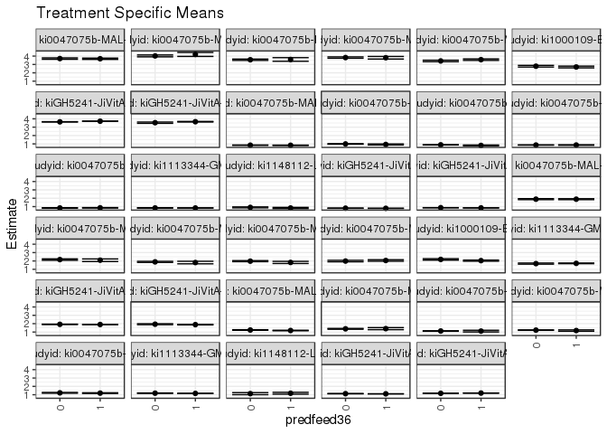

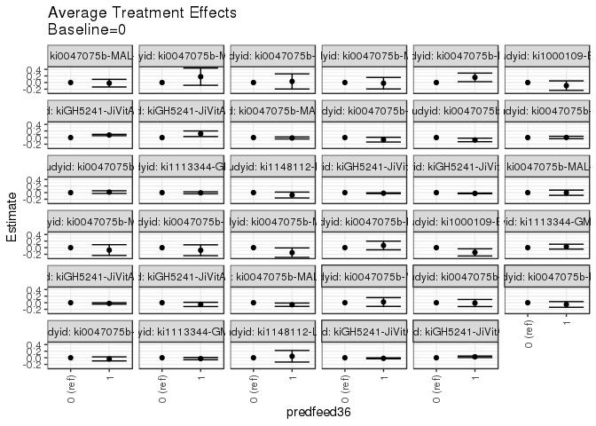

## Results Table

### Parameter: TSM

| agecat | studyid | country | intervention_level | baseline_level | estimate | ci_lower | ci_upper |
| --- | --- | --- | --- | --- | --- | --- | --- |
| 0-3 months | ki0047075b-MAL-ED | BANGLADESH | 0 | NA | 3.7025313 | 3.6178059 | 3.7872567 |
| 0-3 months | ki0047075b-MAL-ED | BANGLADESH | 1 | NA | 3.6835169 | 3.6027732 | 3.7642607 |
| 0-3 months | ki0047075b-MAL-ED | BRAZIL | 0 | NA | 4.0223573 | 3.9108668 | 4.1338477 |
| 0-3 months | ki0047075b-MAL-ED | BRAZIL | 1 | NA | 4.1999747 | 3.9625777 | 4.4373717 |
| 0-3 months | ki0047075b-MAL-ED | INDIA | 0 | NA | 3.5633212 | 3.4831838 | 3.6434587 |
| 0-3 months | ki0047075b-MAL-ED | INDIA | 1 | NA | 3.5964183 | 3.3807361 | 3.8121006 |
| 0-3 months | ki0047075b-MAL-ED | NEPAL | 0 | NA | 3.8233385 | 3.7394027 | 3.9072743 |
| 0-3 months | ki0047075b-MAL-ED | NEPAL | 1 | NA | 3.8031351 | 3.6466157 | 3.9596544 |
| 0-3 months | ki0047075b-MAL-ED | PERU | 0 | NA | 3.4190593 | 3.3318487 | 3.5062699 |
| 0-3 months | ki0047075b-MAL-ED | PERU | 1 | NA | 3.5748715 | 3.4838904 | 3.6658526 |
| 0-3 months | ki1000109-EE | PAKISTAN | 0 | NA | 2.7897429 | 2.6881965 | 2.8912894 |
| 0-3 months | ki1000109-EE | PAKISTAN | 1 | NA | 2.6961263 | 2.5921223 | 2.8001303 |
| 0-3 months | kiGH5241-JiVitA-3 | BANGLADESH | 0 | NA | 3.6367564 | 3.6174180 | 3.6560949 |
| 0-3 months | kiGH5241-JiVitA-3 | BANGLADESH | 1 | NA | 3.7143466 | 3.7021502 | 3.7265431 |
| 0-3 months | kiGH5241-JiVitA-4 | BANGLADESH | 0 | NA | 3.5354100 | 3.4573132 | 3.6135069 |
| 0-3 months | kiGH5241-JiVitA-4 | BANGLADESH | 1 | NA | 3.6511922 | 3.6178539 | 3.6845304 |
| 3-6 months | ki0047075b-MAL-ED | BANGLADESH | 0 | NA | 1.8891720 | 1.8293050 | 1.9490389 |
| 3-6 months | ki0047075b-MAL-ED | BANGLADESH | 1 | NA | 1.8865883 | 1.8284961 | 1.9446804 |
| 3-6 months | ki0047075b-MAL-ED | BRAZIL | 0 | NA | 2.1628084 | 2.0798017 | 2.2458151 |
| 3-6 months | ki0047075b-MAL-ED | BRAZIL | 1 | NA | 2.0898459 | 1.9346619 | 2.2450299 |
| 3-6 months | ki0047075b-MAL-ED | INDIA | 0 | NA | 1.8898024 | 1.8248974 | 1.9547074 |
| 3-6 months | ki0047075b-MAL-ED | INDIA | 1 | NA | 1.8112256 | 1.6593276 | 1.9631235 |
| 3-6 months | ki0047075b-MAL-ED | NEPAL | 0 | NA | 1.9756633 | 1.9152486 | 2.0360779 |
| 3-6 months | ki0047075b-MAL-ED | NEPAL | 1 | NA | 1.8237534 | 1.6935070 | 1.9539998 |
| 3-6 months | ki0047075b-MAL-ED | PERU | 0 | NA | 1.9882438 | 1.8971429 | 2.0793446 |
| 3-6 months | ki0047075b-MAL-ED | PERU | 1 | NA | 2.0554862 | 1.9604692 | 2.1505032 |
| 3-6 months | ki1000109-EE | PAKISTAN | 0 | NA | 2.1830204 | 2.0985033 | 2.2675376 |
| 3-6 months | ki1000109-EE | PAKISTAN | 1 | NA | 2.0396297 | 1.9721696 | 2.1070897 |
| 3-6 months | ki1113344-GMS-Nepal | NEPAL | 0 | NA | 1.6817331 | 1.6145346 | 1.7489316 |
| 3-6 months | ki1113344-GMS-Nepal | NEPAL | 1 | NA | 1.7127474 | 1.6710683 | 1.7544264 |
| 3-6 months | kiGH5241-JiVitA-3 | BANGLADESH | 0 | NA | 1.9191522 | 1.8989889 | 1.9393154 |
| 3-6 months | kiGH5241-JiVitA-3 | BANGLADESH | 1 | NA | 1.8987573 | 1.8863817 | 1.9111328 |
| 3-6 months | kiGH5241-JiVitA-4 | BANGLADESH | 0 | NA | 1.9361242 | 1.8771272 | 1.9951212 |
| 3-6 months | kiGH5241-JiVitA-4 | BANGLADESH | 1 | NA | 1.8845310 | 1.8519975 | 1.9170645 |
| 6-12 months | ki0047075b-MAL-ED | BANGLADESH | 0 | NA | 1.2407860 | 1.2064272 | 1.2751448 |
| 6-12 months | ki0047075b-MAL-ED | BANGLADESH | 1 | NA | 1.1803034 | 1.1480498 | 1.2125570 |
| 6-12 months | ki0047075b-MAL-ED | BRAZIL | 0 | NA | 1.3825236 | 1.3331742 | 1.4318730 |
| 6-12 months | ki0047075b-MAL-ED | BRAZIL | 1 | NA | 1.4043305 | 1.2803905 | 1.5282705 |
| 6-12 months | ki0047075b-MAL-ED | INDIA | 0 | NA | 1.1217871 | 1.0922425 | 1.1513318 |
| 6-12 months | ki0047075b-MAL-ED | INDIA | 1 | NA | 1.1126856 | 1.0090193 | 1.2163518 |
| 6-12 months | ki0047075b-MAL-ED | NEPAL | 0 | NA | 1.2290251 | 1.2020548 | 1.2559955 |
| 6-12 months | ki0047075b-MAL-ED | NEPAL | 1 | NA | 1.1768413 | 1.0955990 | 1.2580836 |
| 6-12 months | ki0047075b-MAL-ED | PERU | 0 | NA | 1.2263365 | 1.1796784 | 1.2729947 |
| 6-12 months | ki0047075b-MAL-ED | PERU | 1 | NA | 1.1925015 | 1.1496678 | 1.2353352 |
| 6-12 months | ki1113344-GMS-Nepal | NEPAL | 0 | NA | 1.1850535 | 1.1546036 | 1.2155035 |
| 6-12 months | ki1113344-GMS-Nepal | NEPAL | 1 | NA | 1.1596985 | 1.1390839 | 1.1803130 |
| 6-12 months | ki1148112-LCNI-5 | MALAWI | 0 | NA | 1.1312222 | 1.0068894 | 1.2555550 |
| 6-12 months | ki1148112-LCNI-5 | MALAWI | 1 | NA | 1.1762933 | 1.0660259 | 1.2865607 |
| 6-12 months | kiGH5241-JiVitA-3 | BANGLADESH | 0 | NA | 1.1273062 | 1.1133523 | 1.1412602 |
| 6-12 months | kiGH5241-JiVitA-3 | BANGLADESH | 1 | NA | 1.1103803 | 1.1027462 | 1.1180144 |
| 6-12 months | kiGH5241-JiVitA-4 | BANGLADESH | 0 | NA | 1.1698500 | 1.1496197 | 1.1900803 |
| 6-12 months | kiGH5241-JiVitA-4 | BANGLADESH | 1 | NA | 1.1990389 | 1.1866791 | 1.2113987 |
| 12-24 months | ki0047075b-MAL-ED | BANGLADESH | 0 | NA | 0.8445298 | 0.8217580 | 0.8673015 |
| 12-24 months | ki0047075b-MAL-ED | BANGLADESH | 1 | NA | 0.8330793 | 0.8126772 | 0.8534814 |
| 12-24 months | ki0047075b-MAL-ED | BRAZIL | 0 | NA | 0.9932777 | 0.9599476 | 1.0266078 |
| 12-24 months | ki0047075b-MAL-ED | BRAZIL | 1 | NA | 0.9305637 | 0.8646770 | 0.9964504 |
| 12-24 months | ki0047075b-MAL-ED | INDIA | 0 | NA | 0.8861740 | 0.8680946 | 0.9042533 |
| 12-24 months | ki0047075b-MAL-ED | INDIA | 1 | NA | 0.8136673 | 0.7629786 | 0.8643560 |
| 12-24 months | ki0047075b-MAL-ED | NEPAL | 0 | NA | 0.8613822 | 0.8444397 | 0.8783247 |
| 12-24 months | ki0047075b-MAL-ED | NEPAL | 1 | NA | 0.8639234 | 0.8312701 | 0.8965768 |
| 12-24 months | ki0047075b-MAL-ED | PERU | 0 | NA | 0.8391194 | 0.8083238 | 0.8699150 |
| 12-24 months | ki0047075b-MAL-ED | PERU | 1 | NA | 0.8547933 | 0.8286203 | 0.8809663 |
| 12-24 months | ki1113344-GMS-Nepal | NEPAL | 0 | NA | 0.8400386 | 0.8141223 | 0.8659549 |
| 12-24 months | ki1113344-GMS-Nepal | NEPAL | 1 | NA | 0.8349884 | 0.8181031 | 0.8518737 |
| 12-24 months | ki1148112-LCNI-5 | MALAWI | 0 | NA | 0.9052456 | 0.8493606 | 0.9611306 |
| 12-24 months | ki1148112-LCNI-5 | MALAWI | 1 | NA | 0.8330056 | 0.7639315 | 0.9020797 |
| 12-24 months | kiGH5241-JiVitA-3 | BANGLADESH | 0 | NA | 0.8109767 | 0.7997269 | 0.8222265 |
| 12-24 months | kiGH5241-JiVitA-3 | BANGLADESH | 1 | NA | 0.7935405 | 0.7873315 | 0.7997495 |
| 12-24 months | kiGH5241-JiVitA-4 | BANGLADESH | 0 | NA | 0.8690399 | 0.8594894 | 0.8785905 |
| 12-24 months | kiGH5241-JiVitA-4 | BANGLADESH | 1 | NA | 0.8455611 | 0.8392589 | 0.8518633 |

### Parameter: E(Y)

| agecat | studyid | country | intervention_level | baseline_level | estimate | ci_lower | ci_upper |
| --- | --- | --- | --- | --- | --- | --- | --- |
| 0-3 months | ki0047075b-MAL-ED | BANGLADESH | NA | NA | 3.5623222 | 3.4990175 | 3.6256270 |
| 0-3 months | ki0047075b-MAL-ED | BRAZIL | NA | NA | 4.0509714 | 3.9492443 | 4.1526985 |
| 0-3 months | ki0047075b-MAL-ED | INDIA | NA | NA | 3.5655176 | 3.4893722 | 3.6416631 |
| 0-3 months | ki0047075b-MAL-ED | NEPAL | NA | NA | 3.8204935 | 3.7444190 | 3.8965681 |
| 0-3 months | ki0047075b-MAL-ED | PERU | NA | NA | 3.3154855 | 3.2518148 | 3.3791562 |
| 0-3 months | ki1000109-EE | PAKISTAN | NA | NA | 2.6575645 | 2.5739973 | 2.7411317 |
| 0-3 months | kiGH5241-JiVitA-3 | BANGLADESH | NA | NA | 3.6935220 | 3.6819690 | 3.7050750 |
| 0-3 months | kiGH5241-JiVitA-4 | BANGLADESH | NA | NA | 3.6272120 | 3.5957777 | 3.6586463 |
| 3-6 months | ki0047075b-MAL-ED | BANGLADESH | NA | NA | 1.9302352 | 1.8809143 | 1.9795560 |
| 3-6 months | ki0047075b-MAL-ED | BRAZIL | NA | NA | 2.1478156 | 2.0686357 | 2.2269955 |
| 3-6 months | ki0047075b-MAL-ED | INDIA | NA | NA | 1.8837264 | 1.8224393 | 1.9450135 |
| 3-6 months | ki0047075b-MAL-ED | NEPAL | NA | NA | 1.9680995 | 1.9120346 | 2.0241643 |
| 3-6 months | ki0047075b-MAL-ED | PERU | NA | NA | 2.0195897 | 1.9536580 | 2.0855214 |
| 3-6 months | ki1000109-EE | PAKISTAN | NA | NA | 2.0241201 | 1.9636505 | 2.0845898 |
| 3-6 months | ki1113344-GMS-Nepal | NEPAL | NA | NA | 1.7041512 | 1.6643719 | 1.7439304 |
| 3-6 months | kiGH5241-JiVitA-3 | BANGLADESH | NA | NA | 1.9109679 | 1.8993348 | 1.9226010 |
| 3-6 months | kiGH5241-JiVitA-4 | BANGLADESH | NA | NA | 1.8963017 | 1.8659335 | 1.9266699 |
| 6-12 months | ki0047075b-MAL-ED | BANGLADESH | NA | NA | 1.1143347 | 1.0894390 | 1.1392304 |
| 6-12 months | ki0047075b-MAL-ED | BRAZIL | NA | NA | 1.3863464 | 1.3400121 | 1.4326807 |
| 6-12 months | ki0047075b-MAL-ED | INDIA | NA | NA | 1.1210558 | 1.0926349 | 1.1494766 |
| 6-12 months | ki0047075b-MAL-ED | NEPAL | NA | NA | 1.2224454 | 1.1966480 | 1.2482429 |
| 6-12 months | ki0047075b-MAL-ED | PERU | NA | NA | 1.2102315 | 1.1775158 | 1.2429472 |
| 6-12 months | ki1113344-GMS-Nepal | NEPAL | NA | NA | 1.1652836 | 1.1455437 | 1.1850235 |
| 6-12 months | ki1148112-LCNI-5 | MALAWI | NA | NA | 1.2437855 | 1.1489803 | 1.3385906 |
| 6-12 months | kiGH5241-JiVitA-3 | BANGLADESH | NA | NA | 1.1137217 | 1.1063529 | 1.1210904 |
| 6-12 months | kiGH5241-JiVitA-4 | BANGLADESH | NA | NA | 1.2021162 | 1.1906438 | 1.2135885 |
| 12-24 months | ki0047075b-MAL-ED | BANGLADESH | NA | NA | 0.8466791 | 0.8306555 | 0.8627027 |
| 12-24 months | ki0047075b-MAL-ED | BRAZIL | NA | NA | 0.9816245 | 0.9508764 | 1.0123725 |
| 12-24 months | ki0047075b-MAL-ED | INDIA | NA | NA | 0.8803730 | 0.8630530 | 0.8976931 |
| 12-24 months | ki0047075b-MAL-ED | NEPAL | NA | NA | 0.8617083 | 0.8463512 | 0.8770654 |
| 12-24 months | ki0047075b-MAL-ED | PERU | NA | NA | 0.8463453 | 0.8256453 | 0.8670453 |
| 12-24 months | ki1113344-GMS-Nepal | NEPAL | NA | NA | 0.8352708 | 0.8193000 | 0.8512417 |
| 12-24 months | ki1148112-LCNI-5 | MALAWI | NA | NA | 0.8835736 | 0.8376943 | 0.9294529 |
| 12-24 months | kiGH5241-JiVitA-3 | BANGLADESH | NA | NA | 0.7961751 | 0.7903156 | 0.8020346 |
| 12-24 months | kiGH5241-JiVitA-4 | BANGLADESH | NA | NA | 0.8490566 | 0.8431830 | 0.8549302 |

### Parameter: ATE

| agecat | studyid | country | intervention_level | baseline_level | estimate | ci_lower | ci_upper |
| --- | --- | --- | --- | --- | --- | --- | --- |
| 0-3 months | ki0047075b-MAL-ED | BANGLADESH | 0 | 0 | 0.0000000 | 0.0000000 | 0.0000000 |
| 0-3 months | ki0047075b-MAL-ED | BANGLADESH | 1 | 0 | -0.0190143 | -0.1346778 | 0.0966491 |
| 0-3 months | ki0047075b-MAL-ED | BRAZIL | 0 | 0 | 0.0000000 | 0.0000000 | 0.0000000 |
| 0-3 months | ki0047075b-MAL-ED | BRAZIL | 1 | 0 | 0.1776174 | -0.0839937 | 0.4392286 |
| 0-3 months | ki0047075b-MAL-ED | INDIA | 0 | 0 | 0.0000000 | 0.0000000 | 0.0000000 |
| 0-3 months | ki0047075b-MAL-ED | INDIA | 1 | 0 | 0.0330971 | -0.1961623 | 0.2623565 |
| 0-3 months | ki0047075b-MAL-ED | NEPAL | 0 | 0 | 0.0000000 | 0.0000000 | 0.0000000 |
| 0-3 months | ki0047075b-MAL-ED | NEPAL | 1 | 0 | -0.0202034 | -0.1952270 | 0.1548202 |
| 0-3 months | ki0047075b-MAL-ED | PERU | 0 | 0 | 0.0000000 | 0.0000000 | 0.0000000 |
| 0-3 months | ki0047075b-MAL-ED | PERU | 1 | 0 | 0.1558122 | 0.0261735 | 0.2854508 |
| 0-3 months | ki1000109-EE | PAKISTAN | 0 | 0 | 0.0000000 | 0.0000000 | 0.0000000 |
| 0-3 months | ki1000109-EE | PAKISTAN | 1 | 0 | -0.0936167 | -0.2373392 | 0.0501059 |
| 0-3 months | kiGH5241-JiVitA-3 | BANGLADESH | 0 | 0 | 0.0000000 | 0.0000000 | 0.0000000 |
| 0-3 months | kiGH5241-JiVitA-3 | BANGLADESH | 1 | 0 | 0.0775902 | 0.0565823 | 0.0985981 |
| 0-3 months | kiGH5241-JiVitA-4 | BANGLADESH | 0 | 0 | 0.0000000 | 0.0000000 | 0.0000000 |
| 0-3 months | kiGH5241-JiVitA-4 | BANGLADESH | 1 | 0 | 0.1157822 | 0.0309326 | 0.2006317 |
| 3-6 months | ki0047075b-MAL-ED | BANGLADESH | 0 | 0 | 0.0000000 | 0.0000000 | 0.0000000 |
| 3-6 months | ki0047075b-MAL-ED | BANGLADESH | 1 | 0 | -0.0025837 | -0.0815106 | 0.0763432 |
| 3-6 months | ki0047075b-MAL-ED | BRAZIL | 0 | 0 | 0.0000000 | 0.0000000 | 0.0000000 |
| 3-6 months | ki0047075b-MAL-ED | BRAZIL | 1 | 0 | -0.0729625 | -0.2361210 | 0.0901960 |
| 3-6 months | ki0047075b-MAL-ED | INDIA | 0 | 0 | 0.0000000 | 0.0000000 | 0.0000000 |
| 3-6 months | ki0047075b-MAL-ED | INDIA | 1 | 0 | -0.0785768 | -0.2431303 | 0.0859767 |
| 3-6 months | ki0047075b-MAL-ED | NEPAL | 0 | 0 | 0.0000000 | 0.0000000 | 0.0000000 |
| 3-6 months | ki0047075b-MAL-ED | NEPAL | 1 | 0 | -0.1519098 | -0.2954877 | -0.0083320 |
| 3-6 months | ki0047075b-MAL-ED | PERU | 0 | 0 | 0.0000000 | 0.0000000 | 0.0000000 |
| 3-6 months | ki0047075b-MAL-ED | PERU | 1 | 0 | 0.0672424 | -0.0643366 | 0.1988214 |
| 3-6 months | ki1000109-EE | PAKISTAN | 0 | 0 | 0.0000000 | 0.0000000 | 0.0000000 |
| 3-6 months | ki1000109-EE | PAKISTAN | 1 | 0 | -0.1433908 | -0.2514979 | -0.0352836 |
| 3-6 months | ki1113344-GMS-Nepal | NEPAL | 0 | 0 | 0.0000000 | 0.0000000 | 0.0000000 |
| 3-6 months | ki1113344-GMS-Nepal | NEPAL | 1 | 0 | 0.0310143 | -0.0427285 | 0.1047571 |
| 3-6 months | kiGH5241-JiVitA-3 | BANGLADESH | 0 | 0 | 0.0000000 | 0.0000000 | 0.0000000 |
| 3-6 months | kiGH5241-JiVitA-3 | BANGLADESH | 1 | 0 | -0.0203949 | -0.0426991 | 0.0019093 |
| 3-6 months | kiGH5241-JiVitA-4 | BANGLADESH | 0 | 0 | 0.0000000 | 0.0000000 | 0.0000000 |
| 3-6 months | kiGH5241-JiVitA-4 | BANGLADESH | 1 | 0 | -0.0515932 | -0.1163449 | 0.0131585 |
| 6-12 months | ki0047075b-MAL-ED | BANGLADESH | 0 | 0 | 0.0000000 | 0.0000000 | 0.0000000 |
| 6-12 months | ki0047075b-MAL-ED | BANGLADESH | 1 | 0 | -0.0604826 | -0.1108070 | -0.0101582 |
| 6-12 months | ki0047075b-MAL-ED | BRAZIL | 0 | 0 | 0.0000000 | 0.0000000 | 0.0000000 |
| 6-12 months | ki0047075b-MAL-ED | BRAZIL | 1 | 0 | 0.0218069 | -0.1111526 | 0.1547664 |
| 6-12 months | ki0047075b-MAL-ED | INDIA | 0 | 0 | 0.0000000 | 0.0000000 | 0.0000000 |
| 6-12 months | ki0047075b-MAL-ED | INDIA | 1 | 0 | -0.0091016 | -0.1168956 | 0.0986925 |
| 6-12 months | ki0047075b-MAL-ED | NEPAL | 0 | 0 | 0.0000000 | 0.0000000 | 0.0000000 |
| 6-12 months | ki0047075b-MAL-ED | NEPAL | 1 | 0 | -0.0521838 | -0.1377854 | 0.0334177 |
| 6-12 months | ki0047075b-MAL-ED | PERU | 0 | 0 | 0.0000000 | 0.0000000 | 0.0000000 |
| 6-12 months | ki0047075b-MAL-ED | PERU | 1 | 0 | -0.0338351 | -0.0954161 | 0.0277460 |
| 6-12 months | ki1113344-GMS-Nepal | NEPAL | 0 | 0 | 0.0000000 | 0.0000000 | 0.0000000 |
| 6-12 months | ki1113344-GMS-Nepal | NEPAL | 1 | 0 | -0.0253551 | -0.0595912 | 0.0088810 |
| 6-12 months | ki1148112-LCNI-5 | MALAWI | 0 | 0 | 0.0000000 | 0.0000000 | 0.0000000 |
| 6-12 months | ki1148112-LCNI-5 | MALAWI | 1 | 0 | 0.0450711 | -0.1305905 | 0.2207327 |
| 6-12 months | kiGH5241-JiVitA-3 | BANGLADESH | 0 | 0 | 0.0000000 | 0.0000000 | 0.0000000 |
| 6-12 months | kiGH5241-JiVitA-3 | BANGLADESH | 1 | 0 | -0.0169259 | -0.0318107 | -0.0020411 |
| 6-12 months | kiGH5241-JiVitA-4 | BANGLADESH | 0 | 0 | 0.0000000 | 0.0000000 | 0.0000000 |
| 6-12 months | kiGH5241-JiVitA-4 | BANGLADESH | 1 | 0 | 0.0291889 | 0.0064651 | 0.0519128 |
| 12-24 months | ki0047075b-MAL-ED | BANGLADESH | 0 | 0 | 0.0000000 | 0.0000000 | 0.0000000 |
| 12-24 months | ki0047075b-MAL-ED | BANGLADESH | 1 | 0 | -0.0114504 | -0.0419213 | 0.0190204 |
| 12-24 months | ki0047075b-MAL-ED | BRAZIL | 0 | 0 | 0.0000000 | 0.0000000 | 0.0000000 |
| 12-24 months | ki0047075b-MAL-ED | BRAZIL | 1 | 0 | -0.0627140 | -0.1352453 | 0.0098173 |
| 12-24 months | ki0047075b-MAL-ED | INDIA | 0 | 0 | 0.0000000 | 0.0000000 | 0.0000000 |
| 12-24 months | ki0047075b-MAL-ED | INDIA | 1 | 0 | -0.0725067 | -0.1262582 | -0.0187552 |
| 12-24 months | ki0047075b-MAL-ED | NEPAL | 0 | 0 | 0.0000000 | 0.0000000 | 0.0000000 |
| 12-24 months | ki0047075b-MAL-ED | NEPAL | 1 | 0 | 0.0025412 | -0.0342261 | 0.0393085 |
| 12-24 months | ki0047075b-MAL-ED | PERU | 0 | 0 | 0.0000000 | 0.0000000 | 0.0000000 |
| 12-24 months | ki0047075b-MAL-ED | PERU | 1 | 0 | 0.0156739 | -0.0244712 | 0.0558190 |
| 12-24 months | ki1113344-GMS-Nepal | NEPAL | 0 | 0 | 0.0000000 | 0.0000000 | 0.0000000 |
| 12-24 months | ki1113344-GMS-Nepal | NEPAL | 1 | 0 | -0.0050502 | -0.0357106 | 0.0256101 |
| 12-24 months | ki1148112-LCNI-5 | MALAWI | 0 | 0 | 0.0000000 | 0.0000000 | 0.0000000 |
| 12-24 months | ki1148112-LCNI-5 | MALAWI | 1 | 0 | -0.0722400 | -0.1610902 | 0.0166103 |
| 12-24 months | kiGH5241-JiVitA-3 | BANGLADESH | 0 | 0 | 0.0000000 | 0.0000000 | 0.0000000 |
| 12-24 months | kiGH5241-JiVitA-3 | BANGLADESH | 1 | 0 | -0.0174361 | -0.0297347 | -0.0051375 |
| 12-24 months | kiGH5241-JiVitA-4 | BANGLADESH | 0 | 0 | 0.0000000 | 0.0000000 | 0.0000000 |
| 12-24 months | kiGH5241-JiVitA-4 | BANGLADESH | 1 | 0 | -0.0234788 | -0.0342389 | -0.0127188 |